# R Visualization

## All point shape types in `ggplot2`

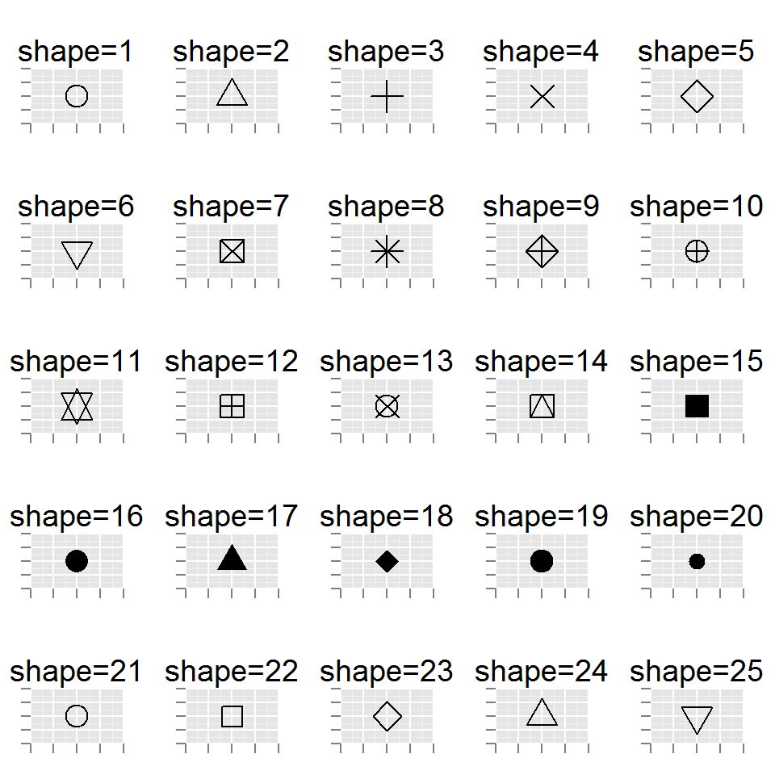

## Grouping: by binary variable

This usually happens accidentally.

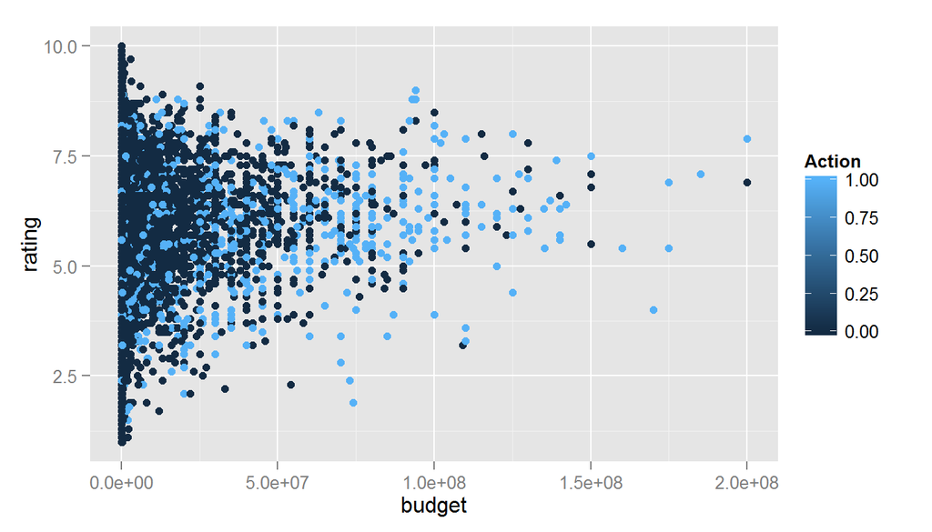

```r
ggplot(movies1, aes(x=budget, y=rating, color=Action)) + geom_point()
```

## Grouping: by categarical variable

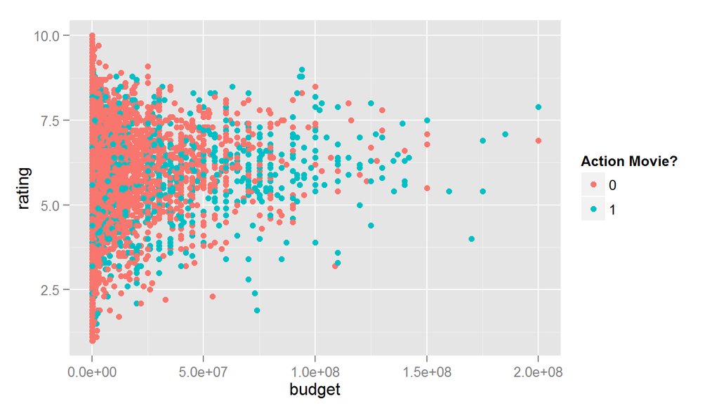

```r
ggplot(movies1, aes(x=budget, y=rating, color=factor(Action))) +
    geom_point() + labs(color='Action Movie?')
```

## Multi-grouping

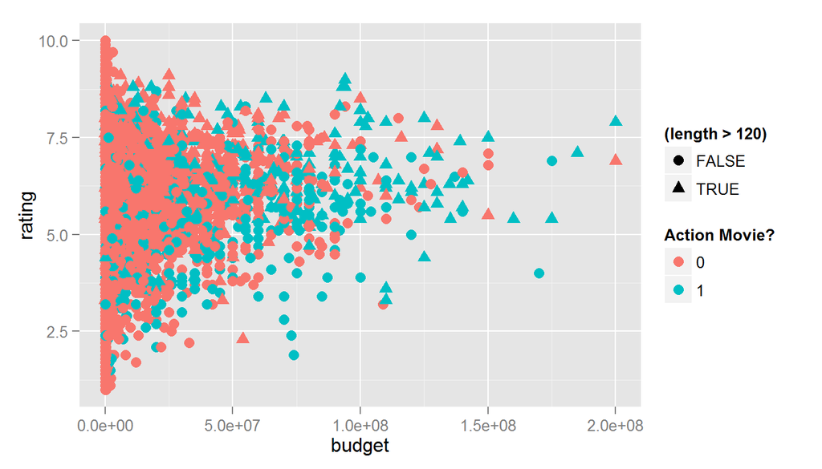

```r
ggplot(movies1, aes(x=budget, y=rating, color=factor(Action), shape=(length > 120))) +
    geom_point(size=3) + labs(color='Action Movie?')
```

## Fit regression line

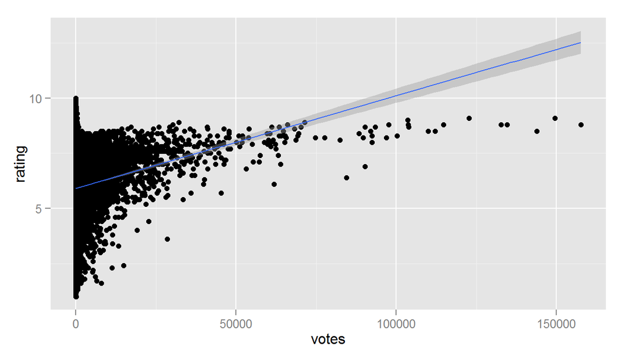

```r
ggplot(movies, aes(x=votes, y=rating)) + geom_point() +
    stat_smooth(method=lm, level=.95) # add se=FALSE to disable CI
```

## The default is a polynomial fit

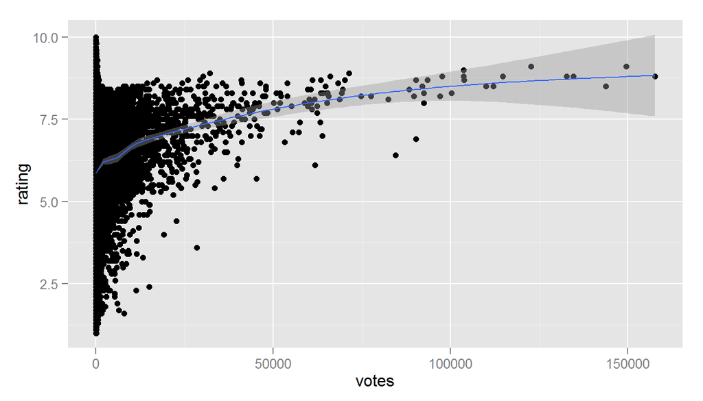

```r
ggplot(movies, aes(x=votes, y=rating)) + geom_point() + stat_smooth()
```

## Fitting is smart to align with grouping

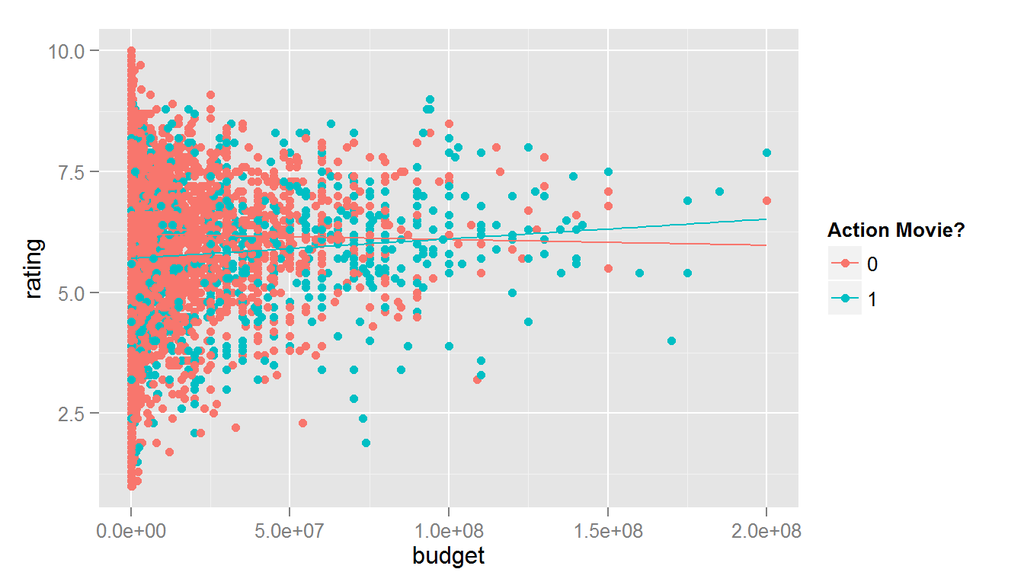

```r
ggplot(movies1, aes(x=budget, y=rating, color=factor(Action))) +
    geom_point() + labs(color='Action Movie?') + stat_smooth(method=lm, se=FALSE)
```

## What if the model is pre-computed?

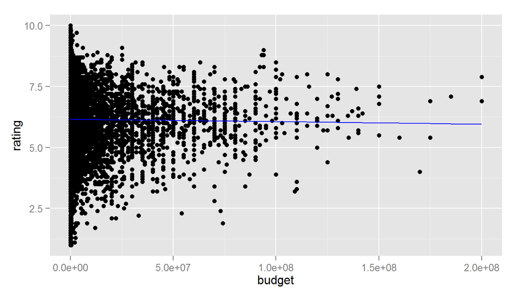

```r
lm_model <- lm(rating ~ budget, data=movies1)
ggplot(movies1, aes(x=budget, y=rating)) + geom_point() +
    geom_line(aes(x=budget, y=lm_model$fitted.values), color='blue')
```

## Scatter plot "as is": Using `geom_text`

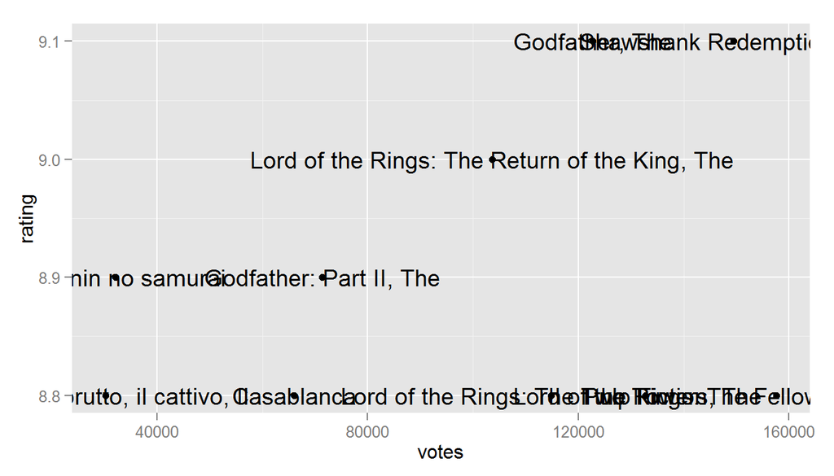

```r
starmovies <- movies[movies$votes > mean(movies$votes),]
starmovies <- starmovies[order(-starmovies$rating),][1:10,]
ggplot(starmovies, aes(x=votes, y=rating)) + geom_point() + geom_text(aes(label=title))
```

## Fine-tune

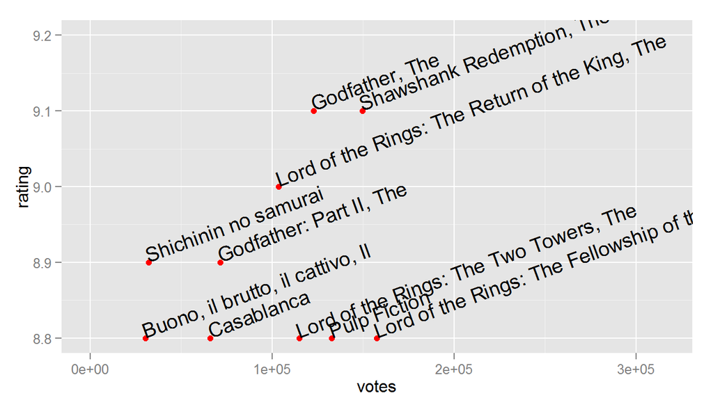

```r
ggplot(starmovies, aes(x=votes, y=rating)) + geom_point(color='red') +
    geom_text(aes(label=title), hjust=0, vjust=0, angle=20) +
    xlim(0, max(starmovies$votes)*2) +
    ylim(min(starmovies$rating), 9.2)
```

## Which Type of Film Cost the Most in Average?

We only choose the movies with single type to simplify the question.

```r
movietype <- colnames(movies)[18:24]
movies1_singletype <- movies1[rowSums(movies1[, movietype]) == 1,] # remove multi-typed
movietype_alt <- c(movietype[length(movietype)], movietype[-length(movietype)])
# convert multiple dummies into one factor as grouping var
# a little matrix operation will do the trick
dummies <- as.matrix(movies1_singletype[, movietype_alt])
movies1_singletype$Type <- factor(dummies %*% (1:length(movietype_alt)), labels=movietype_alt)

# Compute the Average Budget of Each Type
tapply(movies1_singletype$budget, movies1_singletype$Type, mean)
```

```
##       Short      Action   Animation      Comedy       Drama Documentary
##    396133.1  32698189.6  32311451.6  11921970.6  10456690.5    729704.8
##     Romance
##   5603688.0
```

## Determine the variation

The first factor level of movietype, `Short`, is represented as the intercept term.

```r
lmfit <- lm(as.formula("budget ~ Type"), movies1_singletype)
summary(lmfit)$coef
```

```
##                   Estimate Std. Error    t value     Pr(>|t|)
## (Intercept)       396133.1    1715935  0.2308556 8.174455e-01
## TypeAction      32302056.5    2062063 15.6649187 7.005190e-53
## TypeAnimation   31915318.5    4157723  7.6761525 2.316874e-14
## TypeComedy      11525837.5    1888686  6.1025705 1.202481e-09
## TypeDrama       10060557.4    1820528  5.5261750 3.604075e-08
## TypeDocumentary   333571.7    2881175  0.1157763 9.078389e-01
## TypeRomance      5207554.9    3713295  1.4024082 1.609149e-01
```

## Another way to estimate the coefficients

The last predictor, `Short` is combined into the intercept term.

```r
# mean(movies1_singletype[movies1_singletype$Animation == 1, 'budget'])
lmfit <- lm(as.formula(paste('budget ~', paste(movietype, collapse=' + '))),
            movies1_singletype)
summary(lmfit)$coef
```

```
##               Estimate Std. Error    t value     Pr(>|t|)
## (Intercept)   396133.1    1715935  0.2308556 8.174455e-01
## Action      32302056.5    2062063 15.6649187 7.005190e-53
## Animation   31915318.5    4157723  7.6761525 2.316874e-14
## Comedy      11525837.5    1888686  6.1025705 1.202481e-09
## Drama       10060557.4    1820528  5.5261750 3.604075e-08
## Documentary   333571.7    2881175  0.1157763 9.078389e-01
## Romance      5207554.9    3713295  1.4024082 1.609149e-01
```

## Draw the regression lines of each type

What is the association between cost and rating, conditional on type?

```r
movies1_reg_plot <- ggplot(movies1_singletype, aes(x=budget, y=rating, color=Type)) +
  geom_point(shape=1) +

  # set fullrange=T will extend the fitted line outside the sample range
  stat_smooth(method=lm, se=FALSE, fullrange=FALSE, size=1.5) +

  # color is the grouping interface, hence scale_color_*
  scale_color_discrete(name='Movie Type: # of samples',
                       labels=paste(levels(movies1_singletype$Type), ': ',
                                    table(movies1_singletype$Type)))
```

## Output

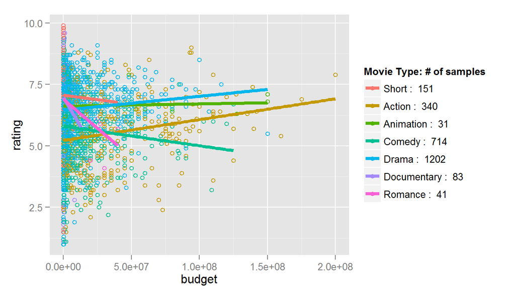

```r
movies1_reg_plot
```

## Exercise: Temprature and RH

Draw a scatter plot of Temprature and RH in Taipei, Taichung, Kaoshiung and Hualien in 2013-05, 2014-05 and 2015-05. Furthermore, each location has its own color and regression line.

Hint: Use following code to read all data and slice the data you want.

```r
source("R/get_weather_all.R")
weather_all <- get_weather_all()
may <- weather_all[weather_all$month == "五月",]
```

## Answer

[figure not shown]

```r
ggplot(may, aes(x=RH, y=Temperature, color=location)) +
    geom_point(shape=1) +
    stat_smooth(method = lm, size = 1.5)
```

## The regression problem behind the scene

```r
interact_terms <- paste(paste(movietype, '*budget', sep=''), collapse=' + ')
lmfit <- lm(as.formula(paste('rating ~', interact_terms)), movies1_singletype)
tail(summary(lmfit)$coef)
```

```
##                         Estimate   Std. Error     t value  Pr(>|t|)
## Action:budget       1.580218e-08 3.331784e-08  0.47428594 0.6353367
## budget:Animation    8.246542e-09 3.379426e-08  0.24402199 0.8072334
## budget:Comedy      -6.222262e-10 3.337127e-08 -0.01864557 0.9851253
## budget:Drama        1.295424e-08 3.333295e-08  0.38863176 0.6975810
## budget:Documentary -8.504501e-08 9.010076e-08 -0.94388788 0.3453164
## budget:Romance     -3.983138e-08 4.086954e-08 -0.97459824 0.3298521
```

- None of the interactive term is statistically significant, indeed
- Visualization != Analysis (Our eyes were not born to work on numbers.)
- Plots can be easily manipluated to be misleading, accidentally or on purpose

## References

- [ggplot2 Official document](http://ggplot2.org/)
- [R Graphics Cookbook](http://www.cookbook-r.com/Graphs/)
- [Introduction to Programming R](https://github.com/everdark/lecture_rintro)
  - Knowlege of general programming is requisite

## Bonus: Annotation

## Annotation

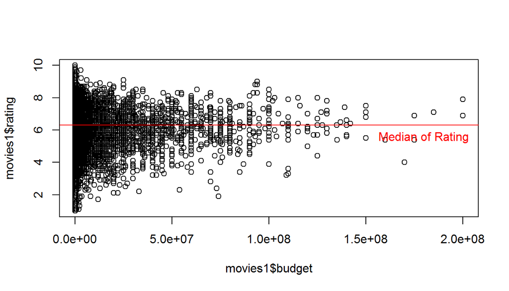

```r
plot(movies1$budget, movies1$rating) # base solution
abline(h=median(movies1$rating), col='red')
text(x=max(movies1$budget)*.9, y=median(movies1$rating),
     labels='Median of Rating', col='red', pos=1)
```

## Annotation: Add lines

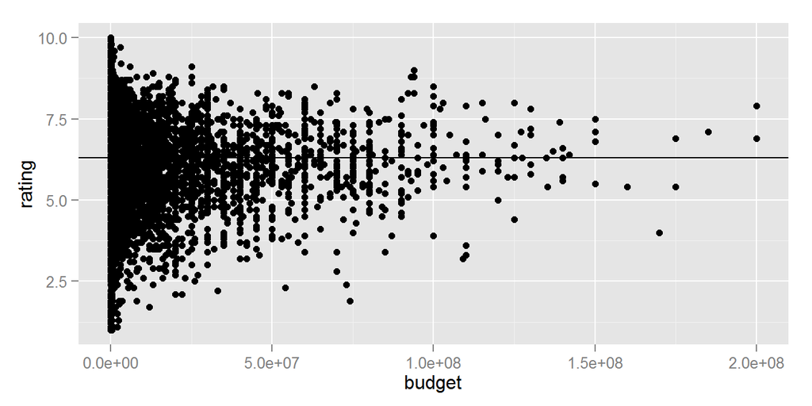

```r
brggp <- ggplot(movies1, aes(x=budget, y=rating)) + geom_point()
brggp + geom_hline(yintercept=median(movies1$rating)) # ?geom_abline for general setup
# brggp + geom_hline(data=movies1, aes(yintercept=median(rating)))  # the same
# brggp + geom_hline(aes(yintercept=median(movies1$rating)))        # the same
```

## Annotation: Add (single) texts

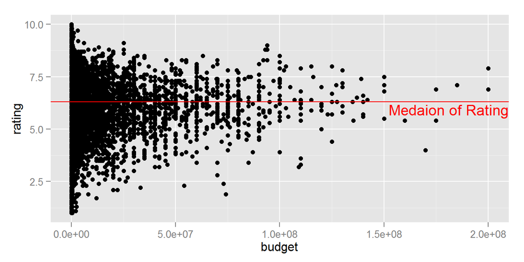

```r
brggp + geom_hline(yintercept=median(movies1$rating), color='red') +
  annotate('text', x=Inf, y=median(movies1$rating),
           label='Medaion of Rating', color='red', vjust=1.2, hjust=1)
# Don't use geom_text for single annotation to avoid overplotting
```

## Annotation: Add segments

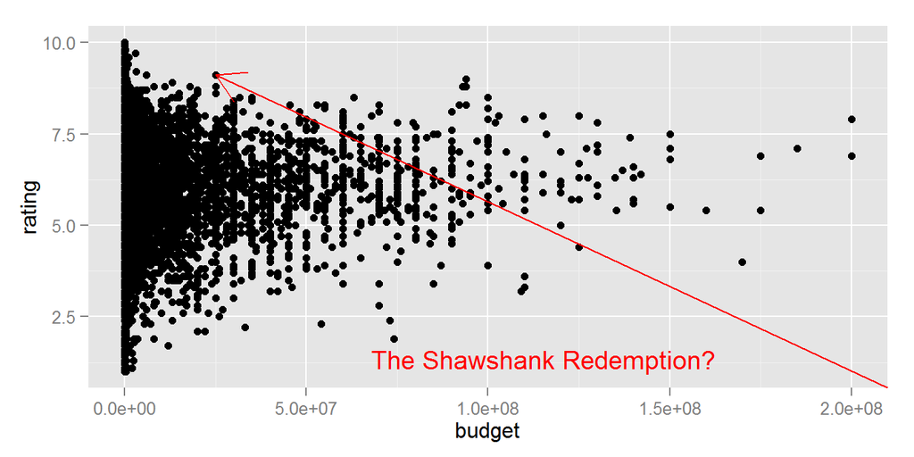

```r
shaw <- movies1[grep('Shawshank Redemption', movies1$title, fixed=TRUE),]
brggp + annotate('segment', xend=shaw$budget, yend=shaw$rating, x=Inf, y=-Inf,
                 arrow=grid::arrow(), color='red') +
  annotate('text', label='The Shawshank Redemption?', x=Inf, y=-Inf,
           hjust=1.5, vjust=-1, color='red')
```

## Annotation: Add shaded area

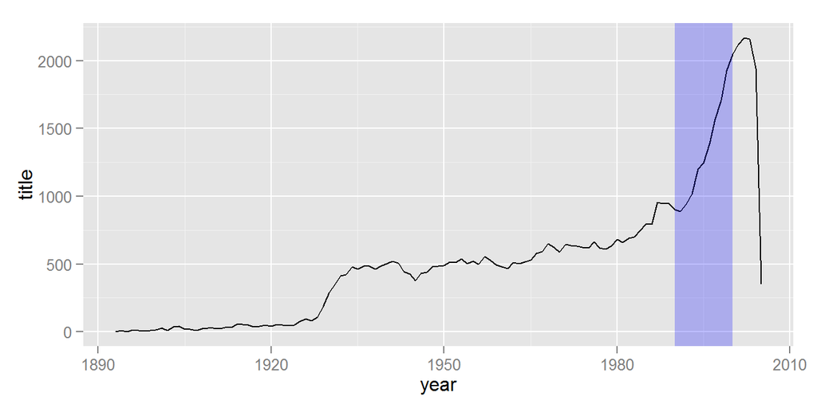

```r
yearcount <- aggregate(title ~ year, data=movies, FUN=length)
ggplot(yearcount, aes(x=year, y=title)) + geom_line() +
  annotate('rect', xmin=1990, xmax=2000, ymin=-Inf, ymax=Inf, fill='blue', alpha=.25)
```

## Bonus: Facet / Multi-plotting

## Facet: Single grouping

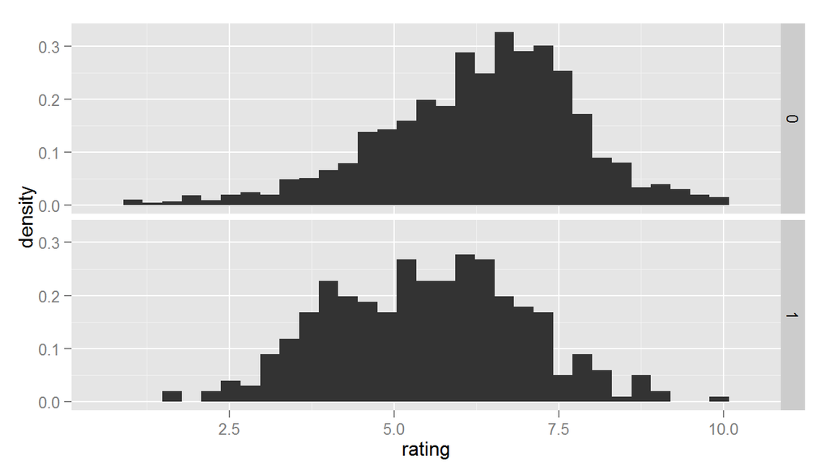

```r
gg <- ggplot(movies1_singletype, aes(x=rating, y=..density..)) + geom_bar()
gg + facet_grid(Action ~ .) # Plot with grouping variable in different window (Vertical)
```

## Facet: Single grouping

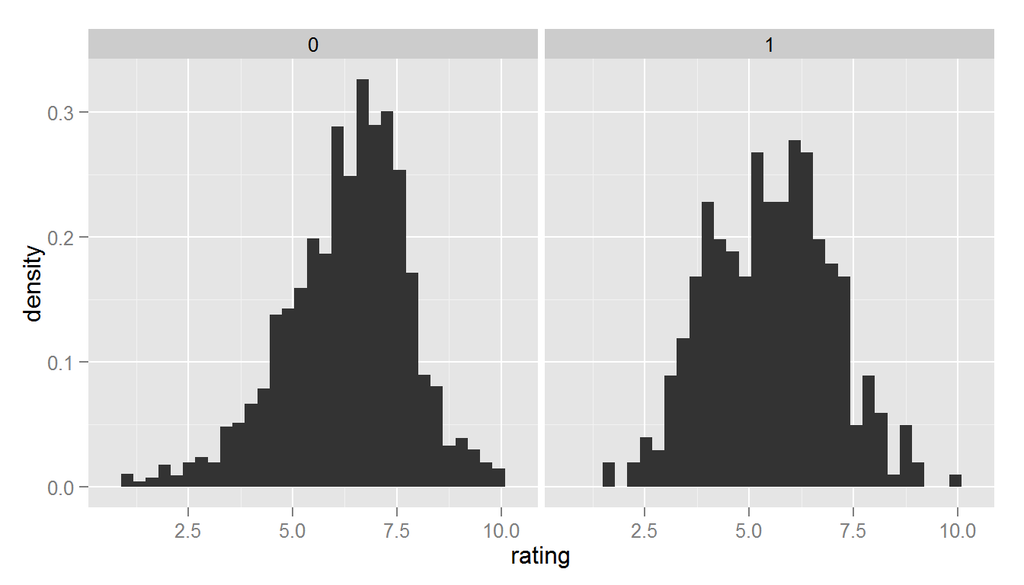

```r
# Plot with grouping variable in different window (Horizontal)
gg + facet_grid(. ~ Action)
```

## Facet: Multiple grouping

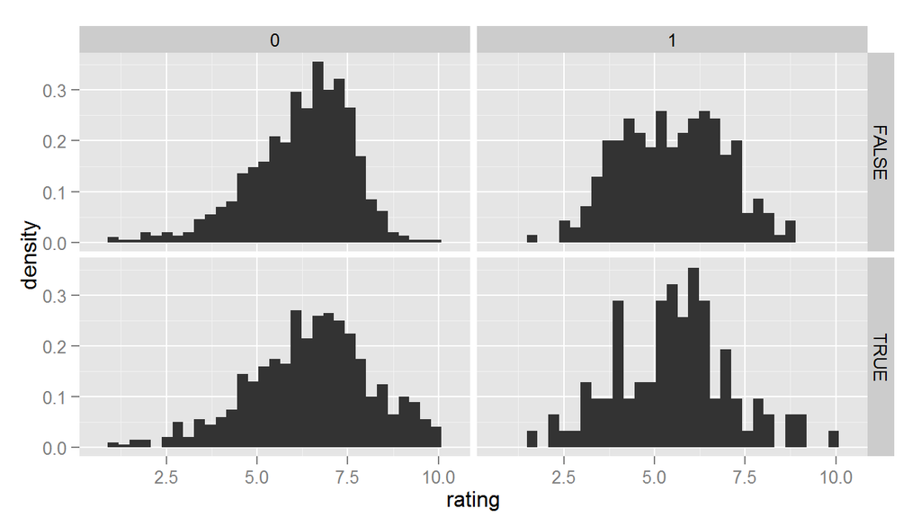

```r
movies1_singletype$modern <- (movies1_singletype$year > 2000)
ggplot(movies1_singletype, aes(x=rating, y=..density..)) +
  geom_bar() + facet_grid(modern ~ Action)
```

## Facet: Multi-layer grouping

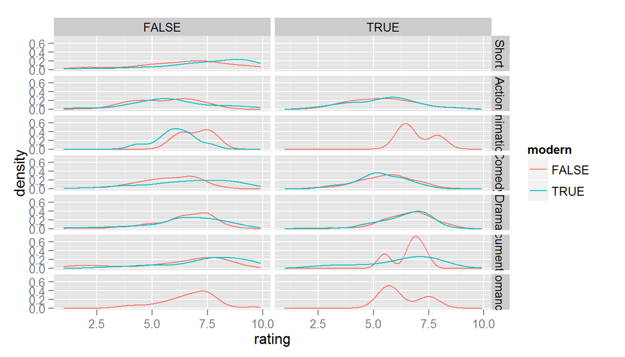

```r
movies1_singletype$rated <- (movies1_singletype$mpaa != '')
ggplot(movies1_singletype, aes(x=rating, color=modern)) +
  geom_line(stat="density") + facet_grid(Type ~ rated)
```

## Facet: Change labels

- Way 1: Change the grouping var in data.frame to reflect the alternate labels
- Way 2: Write customized labeller function for `facet_grid`

```r
print(label_value) # the default labeller plugg in facet_grid(..., labeller)
```

```
## function (variable, value)
## as.character(value)
## <environment: namespace:ggplot2>
```

```r
mylabeller <- function(variable, value){
  if ( variable=='rated' )
    value <- ifelse(value == TRUE, 'Rated Movies', 'Unrated Movies')
  else if ( variable=='Type' )
    as.character(value)
}
```

## Facet: Change labels

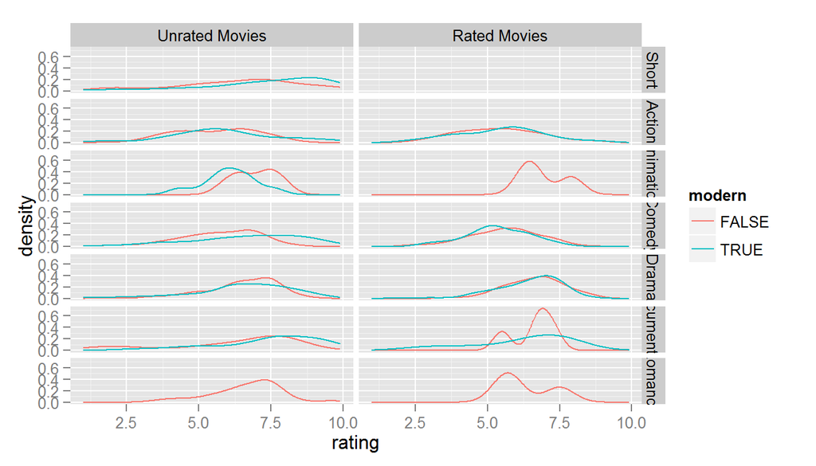

```r
ggplot(movies1_singletype, aes(x=rating, color=modern)) +
  geom_line(stat="density") + facet_grid(Type ~ rated, labeller=mylabeller)
```

## Multi-plotting by `gridExtra` (1/3)

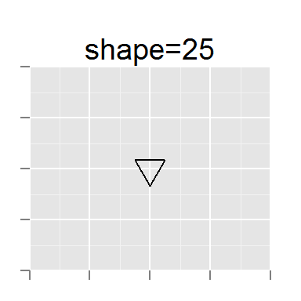

```r
library(gridExtra)
drawPoint <- function(i) {
  ggplot(data.frame(x=1, y=1), aes(x=x,y=y)) +
    geom_point(shape=i, size=5) +
    ggtitle(sprintf('shape=%s',i)) +
    theme(axis.text.x=element_blank(), axis.text.y=element_blank()) +
    xlab(NULL) + ylab(NULL)
  }
drawPoint(25)
```

## Multi-plotting by `gridExtra` (2/3)

```r
symbol_points <- mapply(drawPoint, 1:25, SIMPLIFY=FALSE)
symbols <- do.call(arrangeGrob, symbol_points)
symbols
```

## Multi-plotting by `gridExtra` (3/3)

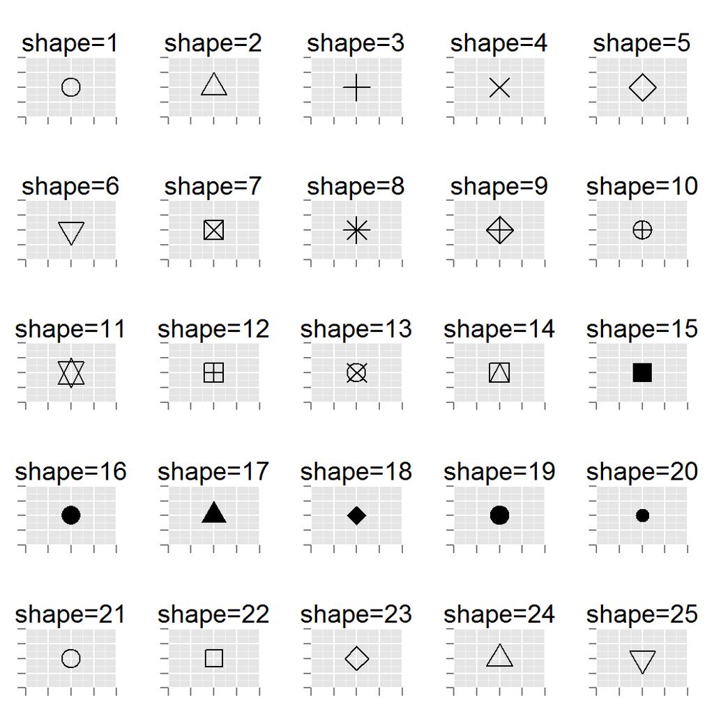

## Line Graph

## It's just that simple!

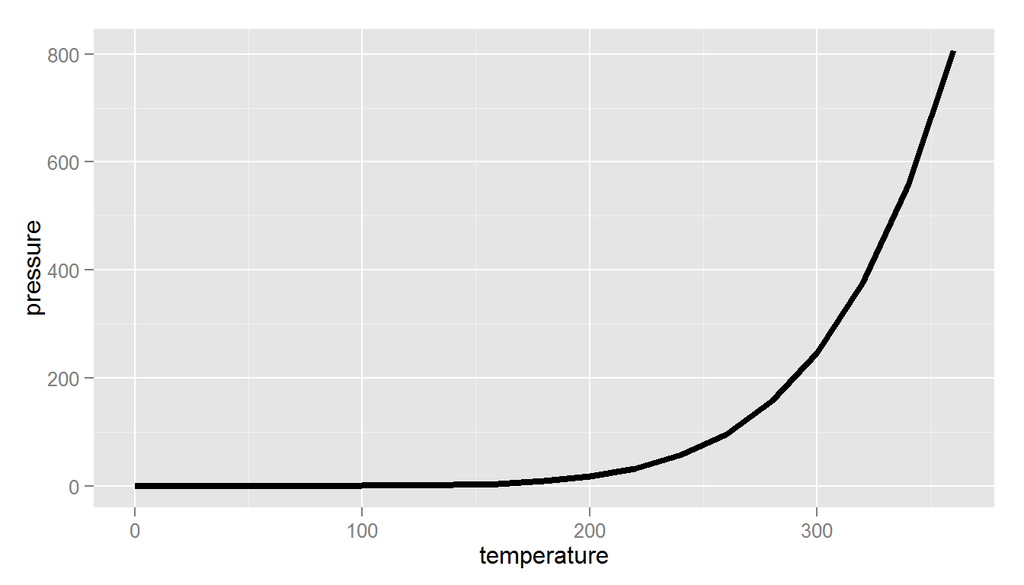

```r
# not meaningful but plottable
ggplot(pressure, aes(x=temperature, y=pressure)) + geom_line(size=1.5)
```

## A Digress: Function Equivalency in `ggplot2`

- Mnay of the parameters can be applied in multiple ways
- `ggtitle('yor title')` is the same as `labs(title='your title')`
- See `?labs` for its equivalent calls
- Many of the functions are siblings of a more general function
- `geom_vline` is the sibling of `geom_abline`
- `theme_bw` is a special version of `theme`
  - The default is `theme_grey`

## Let's try another sameple data

```r
head(WorldPhones)
str(WorldPhones)
```

```
##      N.Amer Europe Asia S.Amer Oceania Africa Mid.Amer
## 1951  45939  21574 2876   1815    1646     89      555
## 1956  60423  29990 4708   2568    2366   1411      733
## 1957  64721  32510 5230   2695    2526   1546      773
## 1958  68484  35218 6662   2845    2691   1663      836
## 1959  71799  37598 6856   3000    2868   1769      911
## 1960  76036  40341 8220   3145    3054   1905     1008
##  num [1:7, 1:7] 45939 60423 64721 68484 71799 ...
##  - attr(*, "dimnames")=List of 2
##   ..$ : chr [1:7] "1951" "1956" "1957" "1958" ...
##   ..$ : chr [1:7] "N.Amer" "Europe" "Asia" "S.Amer" ...
```

## `ggplot`: data.frame only, please!

```r
ggplot(WorldPhones, aes(x=rownames(WorldPhones), y=Asia)) + geom_line()
## Error: ggplot2 doesn't know how to deal with data of class matrix
```

- Remember: `ggplot` eat only data.frames

```r
WorldPhones.DF <- as.data.frame(WorldPhones)
WorldPhones.DF$year <- rownames(WorldPhones.DF)
class(WorldPhones.DF) # this time we should be fine!
```

```
## [1] "data.frame"
```

## What the…?

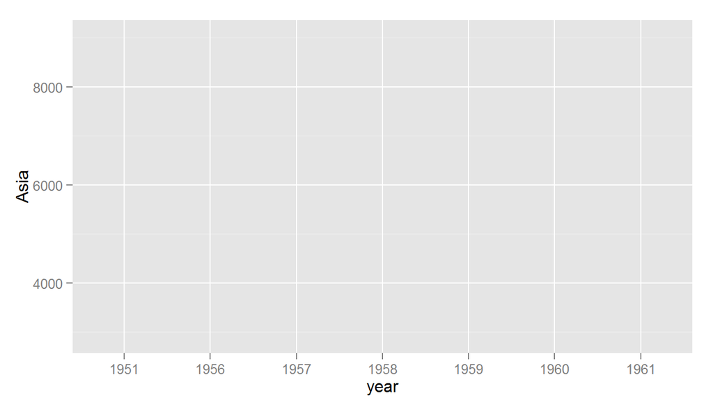

```r
ggplot(WorldPhones.DF, aes(x=year, y=Asia)) + geom_line(size=1.5)
```

## Or simply make x continous, if possible

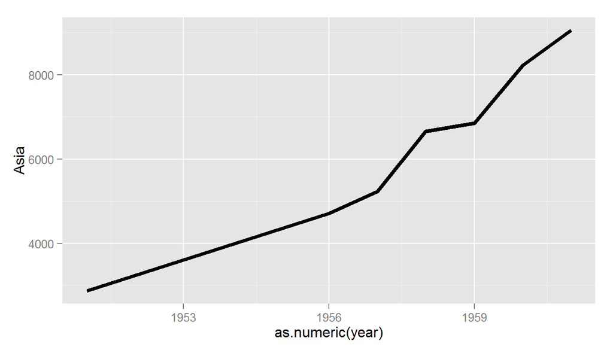

```r
ggplot(WorldPhones.DF, aes(x=as.numeric(year), y=Asia)) + geom_line(size=1.5)
```

## Wait a minute…

Were they really drawn from the same data?

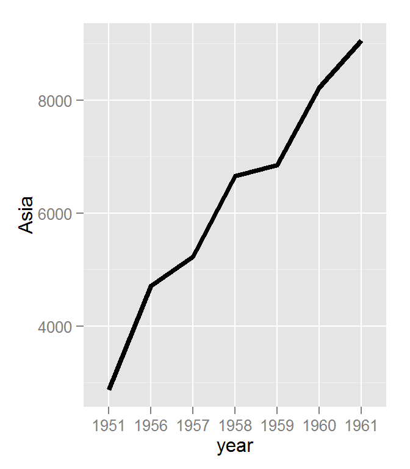

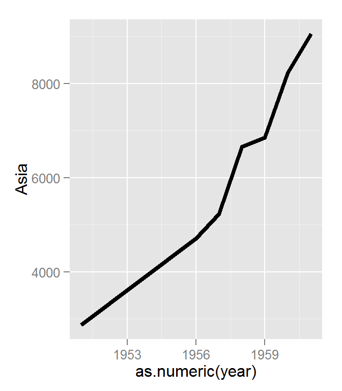

## Can you see the difference?

Remember? Categorical x at default will not show null data.

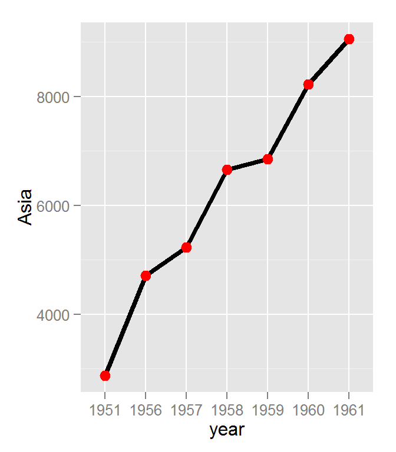

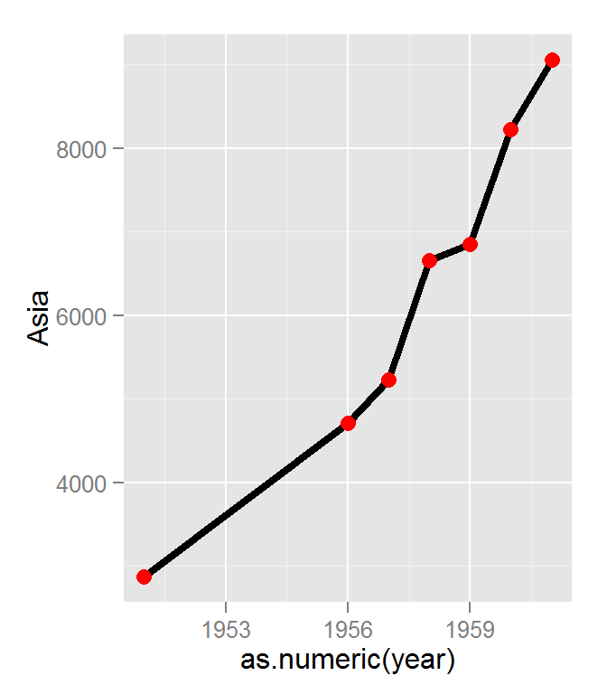

## Multi-lining in `ggplot2`

- Not straightforward, usually need preprocessing
- Only accept **long** format

Wide format

```
##      N.Amer Europe Asia year
## 1951  45939  21574 2876 1951
## 1956  60423  29990 4708 1956
## 1957  64721  32510 5230 1957
## 1958  68484  35218 6662 1958
## 1959  71799  37598 6856 1959
## 1960  76036  40341 8220 1960
## 1961  79831  43173 9053 1961
```

Long format

```
##   Value Region Year
## 1 45939 N.Amer 1951
## 2 60423 N.Amer 1956
## 3 64721 N.Amer 1957
## 4 68484 N.Amer 1958
## 5 71799 N.Amer 1959
## 6 76036 N.Amer 1960
## 7 79831 N.Amer 1961
## 8 21574 Europe 1951
```

## Wide-to-long Conversion

Wide format

```r
WP=WorldPhones.DF[,c(1:3,8)]

head(WP,8)
```

```
##      N.Amer Europe Asia year
## 1951  45939  21574 2876 1951
## 1956  60423  29990 4708 1956
## 1957  64721  32510 5230 1957
## 1958  68484  35218 6662 1958
## 1959  71799  37598 6856 1959
## 1960  76036  40341 8220 1960
## 1961  79831  43173 9053 1961
```

Long format (with melt)

```r
WP.long=melt(WP,id.vars='year')
# 以melt將資料轉換成Long Format，以id.vars保留欄位
colnames(WP.long)=
  c('Year','Region','Value')
head(WP.long)
```

```
##   Year Region Value
## 1 1951 N.Amer 45939
## 2 1956 N.Amer 60423
## 3 1957 N.Amer 64721
## 4 1958 N.Amer 68484
## 5 1959 N.Amer 71799
## 6 1960 N.Amer 76036
```

## The rest is easy!

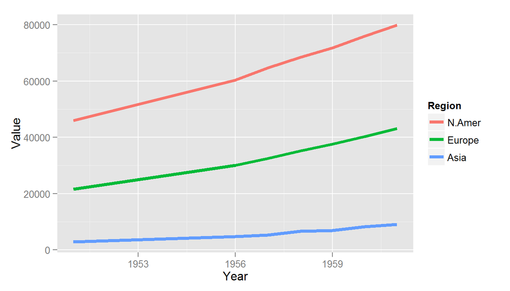

```r
WP.long$Year <- as.integer(as.character(WP.long$Year))
ggplot(WP.long, aes(x=Year, y=Value, color=Region)) + geom_line(size=1.5)
```

## More grouping var: linetype

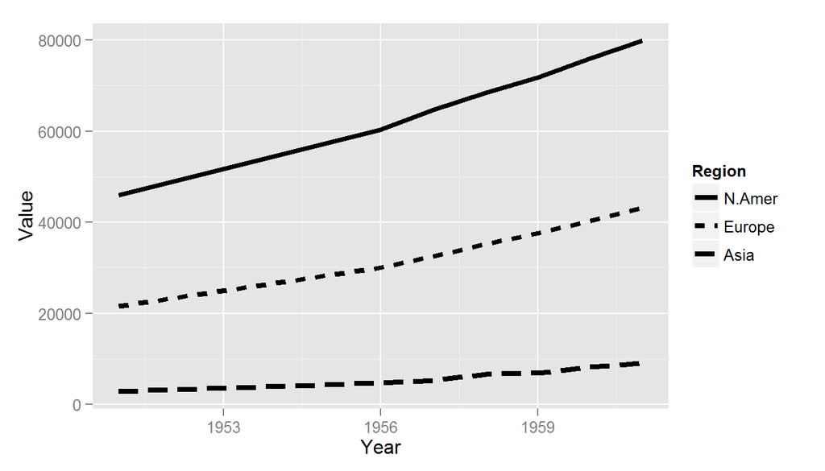

```r
ggplot(WP.long, aes(x=Year, y=Value, linetype=Region))+
  geom_line(size=1.5)
```

## Again, beware of categorical x!

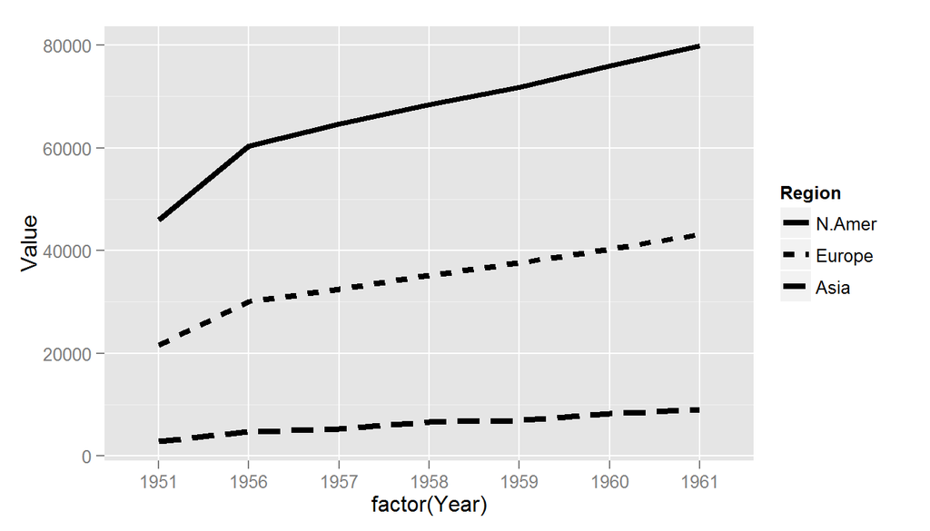

```r
ggplot(WP.long,aes(x=factor(Year), y=Value))+
  geom_line(aes(linetype=Region,group=Region),size=1.5)
```

## Reverse order of legend labels

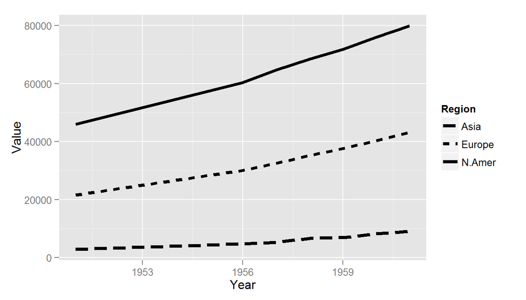

```r
ggplot(WP.long, aes(x=Year, y=Value, linetype=Region)) + geom_line(size=1.5) +
  guides(linetype=guide_legend(reverse=TRUE))
```

## Exercise: Humidity!

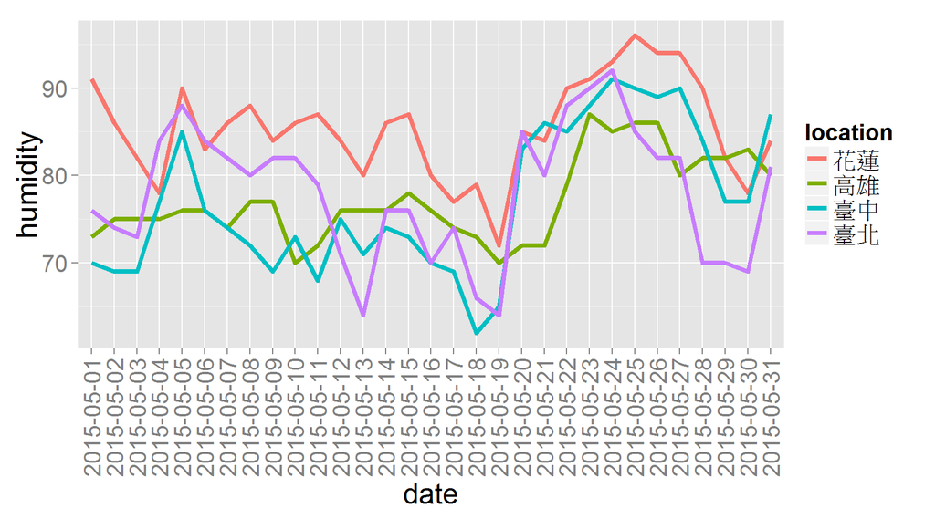

## Exercise: Humidity!- Answer

```r
load('humidity.RData') #load the file
ggplot(humidity,aes(x=date,y=humidity))+
  # 按照location畫圖與填色
  geom_line(aes(group=location,colour=location),size=1.5)+
  # 調整X軸label的文字大小與角度
  theme(axis.text.x = element_text(angle = 90, hjust = 1,vjust=0.5),text=element_text(size=20))
```

## The Grammer of Graphics

## The Anatomy of a Plot

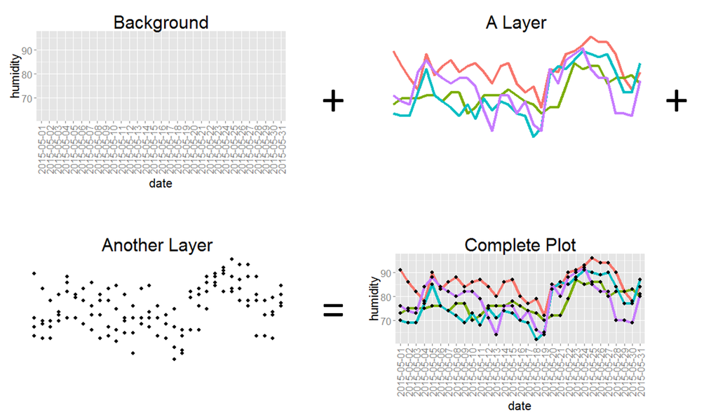

## The Anatomy of a Plot

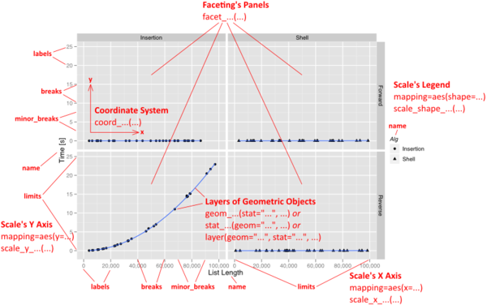

from: http://sape.inf.usi.ch/quick-reference/ggplot2

## Data and Mapping

```r
ggplot(data=humidity)+geom_line(aes(x=date,y=humidity))
```

data

```
##         date location humidity
## 1 2015-05-01     花蓮       91
## 2 2015-05-02     花蓮       86
## 3 2015-05-03     花蓮       82
## 4 2015-05-04     花蓮       78
## 5 2015-05-05     花蓮       90
## 6 2015-05-06     花蓮       83
```

mapping: aes(x=…,y=…)

```
##         date humidity
## 1 2015-05-01       91
## 2 2015-05-02       86
## 3 2015-05-03       82
## 4 2015-05-04       78
## 5 2015-05-05       90
## 6 2015-05-06       83
```

## geometric

geom_line

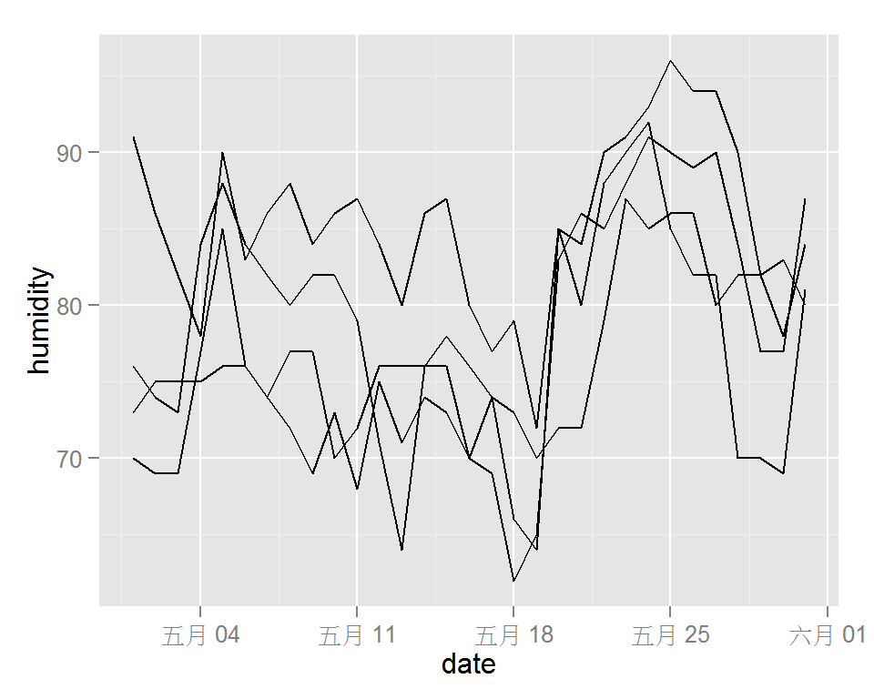

```r
ggplot(humidity,aes(x=date,y=humidity))+
geom_line(aes(group=location))
```

geom_point

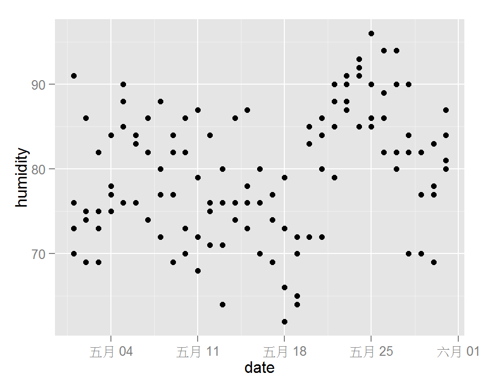

```r
ggplot(humidity,aes(x=date,y=humidity))+
geom_point()
```

## scale

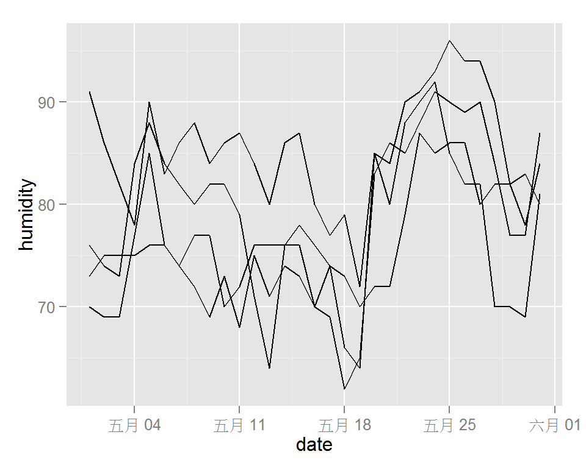

```r
ggplot(humidity,aes(x=date,y=humidity))+
geom_line(aes(group=location))
```

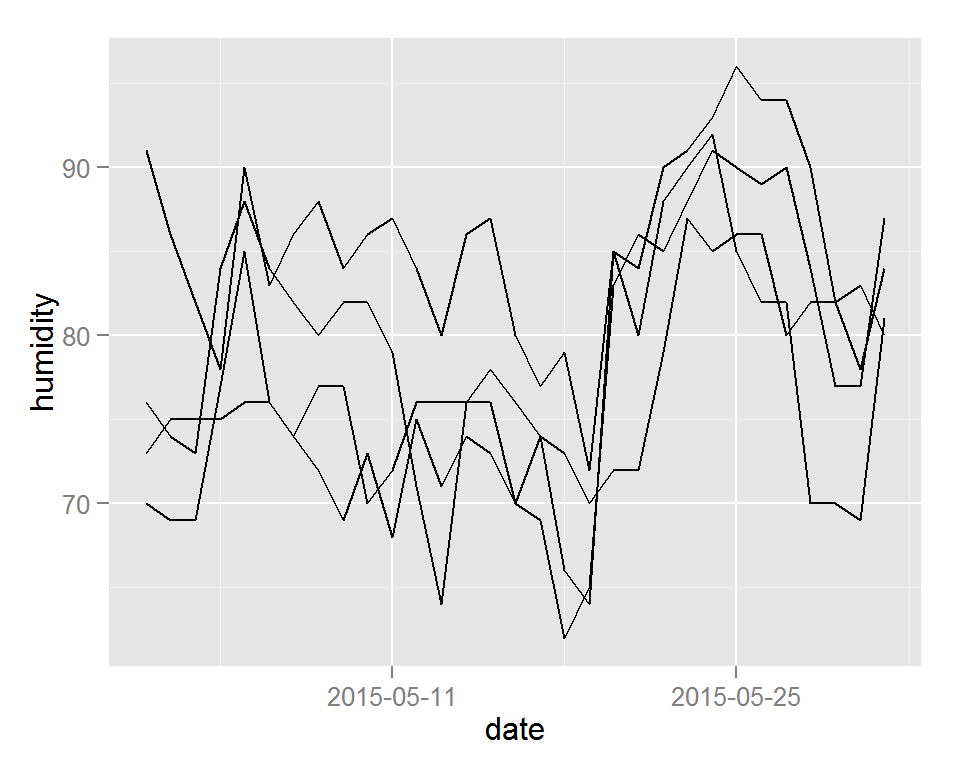

```r
ggplot(humidity,aes(x=date,y=humidity))+
  geom_line(aes(group=location))+
  scale_x_date(breaks = "2 weeks")
```

## statistics

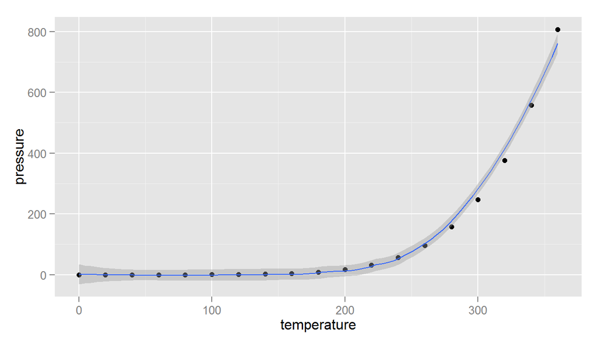

```r
 ggplot(pressure,aes(x=temperature,y=pressure))+
  geom_point()+
  stat_smooth()
```

## coordinante

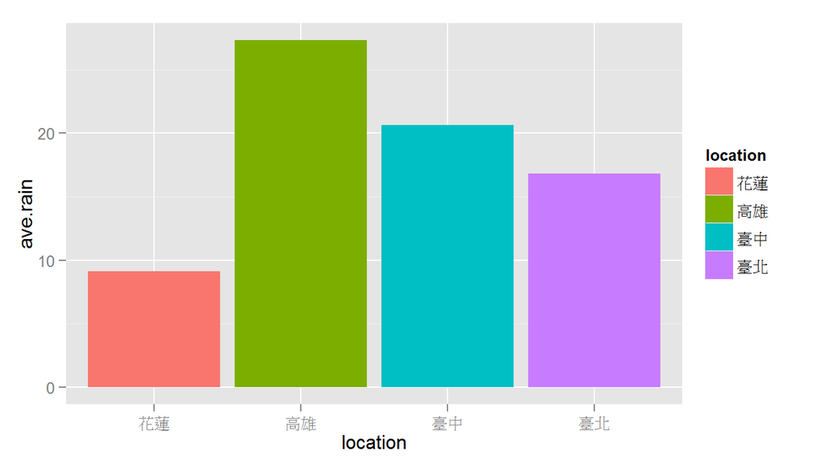

```r
hum=filter(humidity,rainfall>0) %>% select(location,rainfall) %>%
  group_by(location) %>% summarise(ave.rain=mean(rainfall))
ggplot(hum,aes(x=location,y=ave.rain))+geom_bar(aes(fill=location),stat='identity')
```

## coordinante

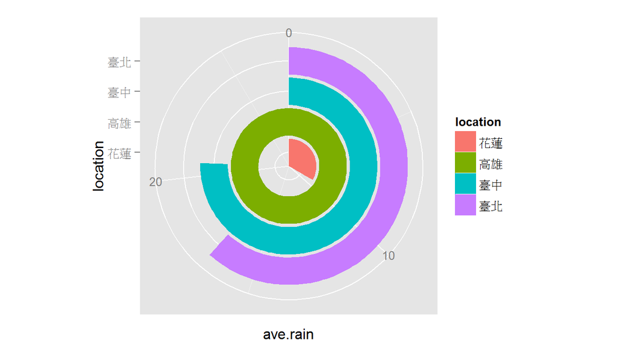

```r
ggplot(hum,aes(x=location,y=ave.rain))+
  geom_bar(aes(fill=location),stat='identity')+
  coord_polar(theta='y')
```

## coordinante

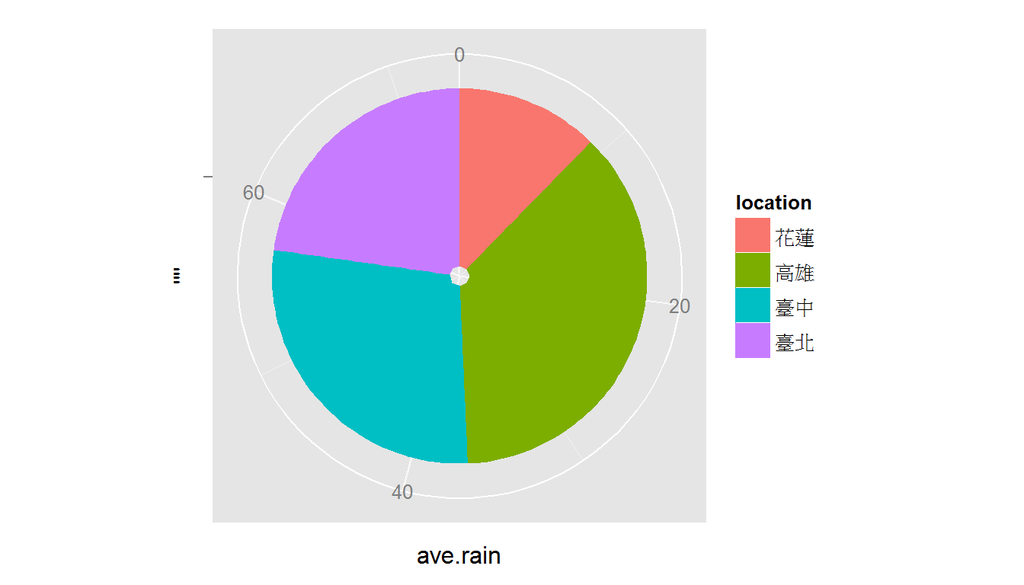

```r
ggplot(hum,aes(x="",y=ave.rain))+
  geom_bar(aes(fill=location),stat='identity')+
  coord_polar(theta='y')
```

## facet

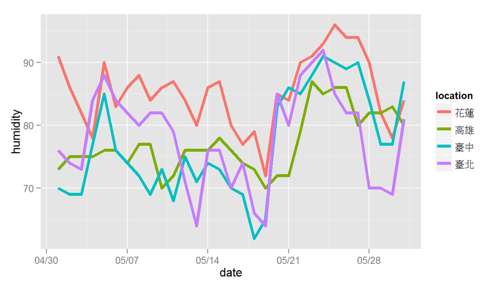

## facet

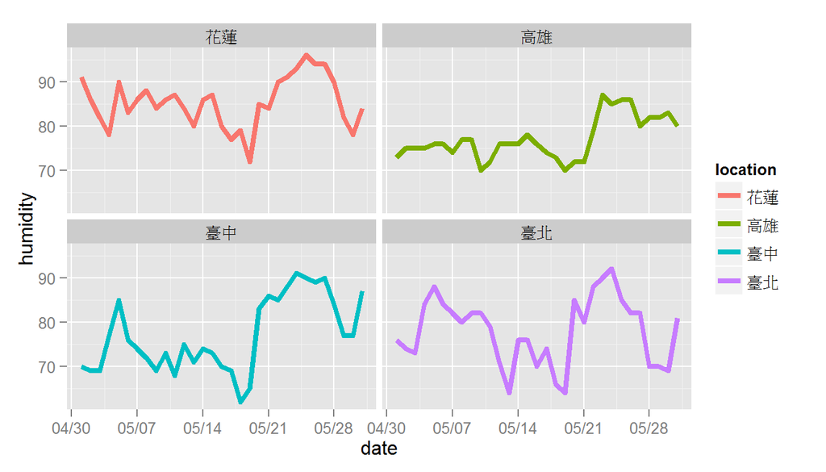

```r
ggplot(humidity,aes(x=date,y=humidity))+
  geom_line(aes(group=location,colour=location),size=1.5)+
  scale_x_date(breaks = "7 days",labels = date_format("%m/%d"))+
  facet_wrap(~location)
```

## theme

- 控制圖中的元素與主題

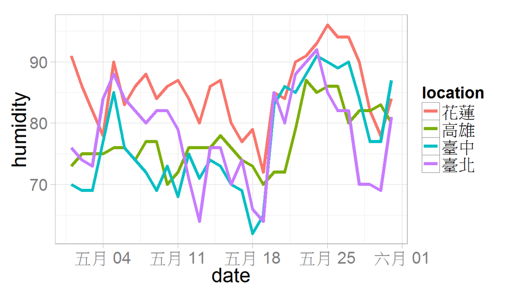

```r
 ggplot(humidity,aes(x=date,y=humidity))+
   geom_line(aes(group=location,colour=location),size=1.5)+
  theme_light(base_size = 20)
```